# ANOVA

21 okt 2015

## ANOVA One-way repeated

Compare subjects on 2 or more repeated measures

## Example

Measure driving ability in a driving simulator. Test in three conditions.

- Alcohol none
- Alcohol some
- Alcohol much

## The data

| pp | none_alc | some_alc | much_alc |
| --- | --- | --- | --- |
| 1 | 4.426 | 4.106 | 7.043 |
| 2 | 4.227 | 5.469 | 5.901 |
| 3 | 5.278 | 5.557 | 7.045 |
| 4 | 4.632 | 5.323 | 6.208 |
| 5 | 5.288 | 5.148 | 6.853 |
| 6 | 5.025 | 5.158 | 6.492 |
| 7 | 4.496 | 5.829 | 6.972 |
| 8 | 5.359 | 6.121 | 6.38 |
| 9 | 4.492 | 5.264 | 6.12 |
| 10 | 3.587 | 4.047 | 6.84 |

[output cut: 10 more lines]

## Formulas

| Variance | Sum of Squares | df | Mean Squares | F-ratio |  |
| --- | --- | --- | --- | --- | --- |
| Between | \({SS}_{{between}} = {SS}_{{total}} - {SS}_{{within}}\) | \({DF}_{{total}}-{DF}_{{within}}\) | \(\frac{{SS}_{{between}}}{{DF}_{{between}}}\) |  |  |
| Within | \({SS}_{{within}} = \sum{s_i^2(n_i-1)}\) | \((n_i-1)n\) | \(\frac{{SS}_{{within}}}{{DF}_{{within}}}\) |  |  |
| • Model | \({SS}_{{model}} = \sum{n_k(\bar{X}_k-\bar{X})^2}\) | \(k-1\) | \(\frac{{SS}_{{model}}}{{DF}_{{model}}}\) | \(\frac{{MS}_{{model}}}{{MS}_{{error}}}\) |  |
| • Error | \({SS}_{{error}} = {SS}_{{within}} - {SS}_{{model}}\) | \((n-1)(k-1)\) | \(\frac{{SS}_{{error}}}{{DF}_{{error}}}\) |  |  |
| Total | \({SS}_{{total}} = s_{grand}^2(N-1)\) | \(N-1\) | \(\frac{{SS}_{{total}}}{{DF}_{{total}}}\) |  |  |

Where \(n_i\) is the number of observations per person and \(k\) is the number of conditions. These two are equal for a one-way repeated ANOVA. Furthermore \(n\) is the number of subjects per condition and \(N\) is the total number of data points \(n \times k\).

## \({MS}_{total}\)

```r
# Assign to individual variables
none_alc = data$none_alc
some_alc = data$some_alc
much_alc = data$much_alc
total    = c(none_alc,some_alc,much_alc)
```

\[{MS}_{total} = \frac{{SS}_{{total}}}{{DF}_{{total}}} = s_{grand}^2\]

```r
MS_total = var(total); MS_total
```

```
## [1] 0.9410458
```

## \({SS}_{total}\)

\[{DF_{total}} = N-1 \\ {SS}_{{total}} = s_{grand}^2(N-1)\]

```r
N = length(total)
DF_total = N - 1
SS_total = MS_total * DF_total; SS_total
```

```
## [1] 55.5217
```

```r
sum((total - mean(total))^2)
```

```
## [1] 55.5217
```

## \({SS}_{total}\) visual

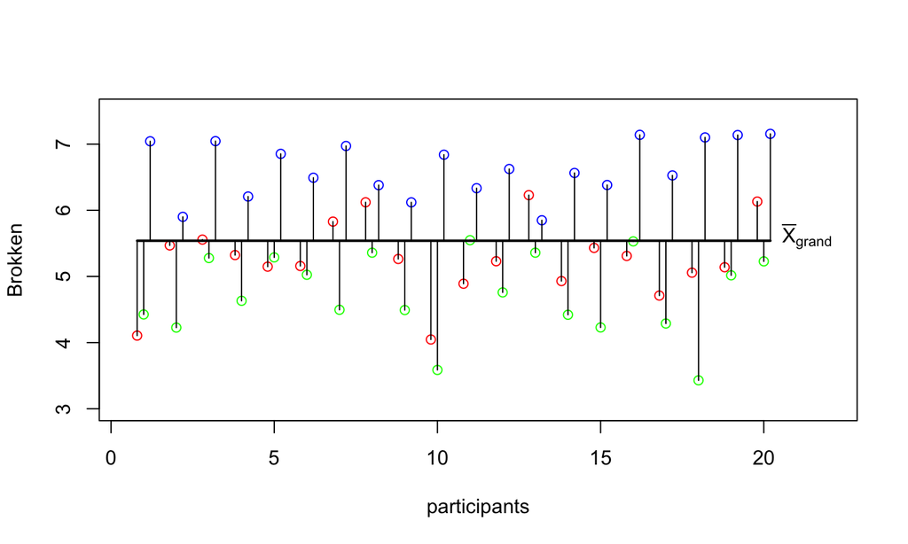

```r
# Set offset
offset = .2

# Calculate n
n = length(none_alc)

# Create plot
plot(none_alc,
     xlab = 'participants',
     ylab = 'Brokken',
     xlim = c(.5,22),
     ylim = c(3,7.5),
     col='green')
points((1:n)-offset, some_alc, col='red')
points((1:n)+offset, much_alc,   col='blue')

# Add the total mean
lines(c((1-offset),(n+offset)),rep(mean(total),2),col='black',lwd=2)

segments(1:n,        mean(total), 1:n,        none_alc)
segments(1:n-offset, mean(total), 1:n-offset, some_alc)
segments(1:n+offset, mean(total), 1:n+offset, much_alc)

text(n+offset,mean(total),expression(bar(X)[grand]),pos=4)
```

```r
p <- recordPlot()
```

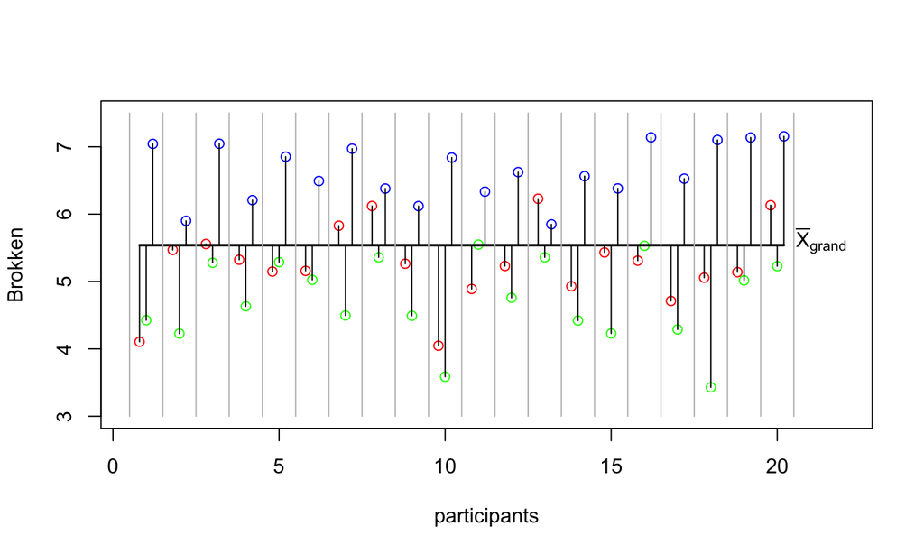

```r
p

# add grid
segments(1:21-.5, 3, 1:21-.5, 7.5, col='grey')
```

```r
p <- recordPlot()
```

## \({MS}_{within}\)

\[{MS}_{within} = \frac{{SS}_{{within}}}{{DF}_{{within}}} \\ {DF}_{within} = (n_i-1)n\]

```r
n.i = 3  # Number of mesurements per individual (none, some, much)
n   = 20 # Number of mesurements per group

DF_within = (n.i - 1) * n
DF_within
```

```
## [1] 40
```

## \({SS}_{within}\)

\[{SS}_{{within}} = \sum{s_i^2(n_i-1)}\]

```r
var_pp = apply(cbind(none_alc, some_alc, much_alc),1,var)
ss_pp  = var_pp * (n.i - 1)

SS_within = sum(ss_pp); SS_within
```

```
## [1] 48.45032
```

```r
mean_pp = apply(cbind(none_alc, some_alc, much_alc),1,mean)

sum(c((none_alc   - mean_pp)^2,
      (some_alc - mean_pp)^2,
      (much_alc   - mean_pp)^2))
```

```
## [1] 48.45032
```

## \({SS}_{within}\) data

| pp | none_alc | some_alc | much_alc | mean_pp | ss_pp |
| --- | --- | --- | --- | --- | --- |
| 1 | 4.426 | 4.106 | 7.043 | 5.192 | 5.192 |
| 2 | 4.227 | 5.469 | 5.901 | 5.199 | 1.51 |
| 3 | 5.278 | 5.557 | 7.045 | 5.96 | 1.805 |
| 4 | 4.632 | 5.323 | 6.208 | 5.388 | 1.248 |
| 5 | 5.288 | 5.148 | 6.853 | 5.763 | 1.792 |
| 6 | 5.025 | 5.158 | 6.492 | 5.558 | 1.316 |
| 7 | 4.496 | 5.829 | 6.972 | 5.766 | 3.071 |
| 8 | 5.359 | 6.121 | 6.38 | 5.953 | 0.563 |
| 9 | 4.492 | 5.264 | 6.12 | 5.292 | 1.326 |
| 10 | 3.587 | 4.047 | 6.84 | 4.825 | 6.198 |

[output cut: 10 more lines]

## \({SS}_{within}\) visual

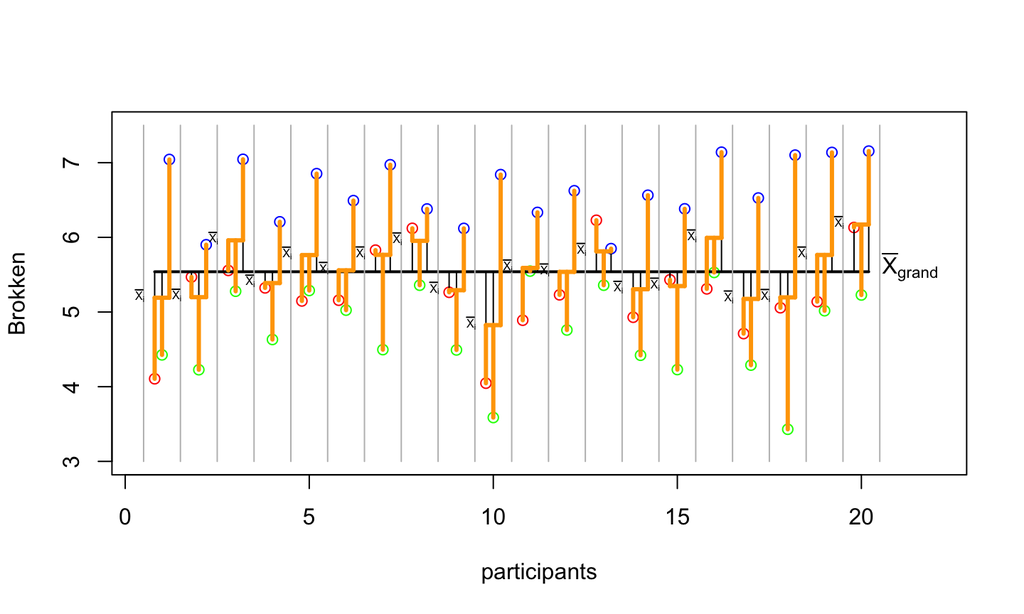

```r
p
# Personal means
segments(1:n-offset, mean_pp, 1:n+offset, mean_pp, col='orange', lwd=3)
# The lines show the within deviation from the personal mean.
segments(1:n-offset, mean_pp, 1:n-offset, some_alc, col='orange', lwd=3)
segments(1:n, mean_pp,        1:n,        none_alc,   col='orange', lwd=3)
segments(1:n+offset, mean_pp, 1:n+offset, much_alc,   col='orange', lwd=3)

# Add personal means symbols
for(i in 1:n) { text(i-(offset/2), mean_pp[i], expression(bar(X)[i]), pos=2, cex=.5)}
```

```r
p <- recordPlot()
```

## \({MS}_{between}\)

\[{MS}_{between} = \frac{{SS}_{{between}}}{{DF}_{{between}}}\]

\[{DF}_{between}-{DF}_{{within}} \\ {SS}_{between} = {SS}_{total} - {SS}_{within}\]

```r
SS_between = SS_total - SS_within
SS_between
```

```
## [1] 7.071382
```

```r
DF_between = DF_total - DF_within
DF_between
```

```
## [1] 19
```

## \({MS}_{model}\)

\[{MS}_{model} = \frac{{SS}_{{model}}}{{DF}_{{model}}} \\ {DF}_{model} = k-1\]

```r
k = 3
DF_model = k - 1
DF_model
```

```
## [1] 2
```

## \({SS}_{model}\)

\[{SS}_{model} = \sum{n_k(\bar{X}_k-\bar{X})^2}\]

```r
# SS model
n_k1 = length(none_alc)
n_k2 = length(some_alc)
n_k3 = length(much_alc)

# Calculate sums of squares for the model
SS_k1 = n_k1 * (mean(none_alc)   - mean(total))^2
SS_k2 = n_k2 * (mean(some_alc) - mean(total))^2
SS_k3 = n_k3 * (mean(much_alc)   - mean(total))^2

SS_model = sum(SS_k1, SS_k2, SS_k3)
SS_model
```

```
## [1] 38.63266
```

## \({SS}_{model}\) visual

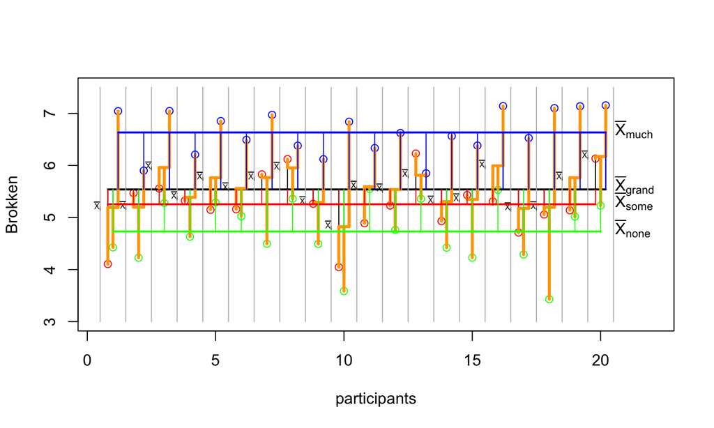

```r
p
# Add the no alcohol mean
lines(c((1),(n)),rep(mean(none_alc),2),col='green',lwd=2)
text(n+offset,mean(none_alc),expression(bar(X)[none]),pos=4)

# With the bit alcohol mean
lines(c((1-offset),(n-offset)),rep(mean(some_alc),2),col='red',lwd=2)
text(n+offset,mean(some_alc),expression(bar(X)[some]),pos=4)

# With the much alcohol mean
lines(c((1+offset),(n+offset)),rep(mean(much_alc),2),col='blue',lwd=2)
text(n+offset,mean(much_alc),expression(bar(X)[much]),pos=4)

# The lines show the model deviation from the total mean.
segments(1:n,        mean(total), 1:n,        mean(none_alc),   col='green')
segments(1:n-offset, mean(total), 1:n-offset, mean(some_alc), col='red')
segments(1:n+offset, mean(total), 1:n+offset, mean(much_alc),   col='blue')
```

```r
p <- recordPlot()
```

## \({MS}_{error}\)

\[\frac{{SS}_{error}}{{DF}_{error}} \\ {DF}_{error} = (n-1)(k-1)\]

```r
DF_error = DF_within - DF_model
DF_error
```

```
## [1] 38
```

## \({SS}_{error}\)

\[{SS}_{error} = {SS}_{within} - {SS}_{model}\]

```r
SS_error = SS_within - SS_model
SS_error
```

```
## [1] 9.817655
```

## F ratio

\[F = \frac{{MS}_{{model}}}{{MS}_{{error}}}\]

```r
# Calculate mean squares
MS_model = SS_model / DF_model
MS_error = SS_error / DF_error

# Calculate F statistic
F = MS_model / MS_error
F
```

```
## [1] 74.76537
```

## Visualize

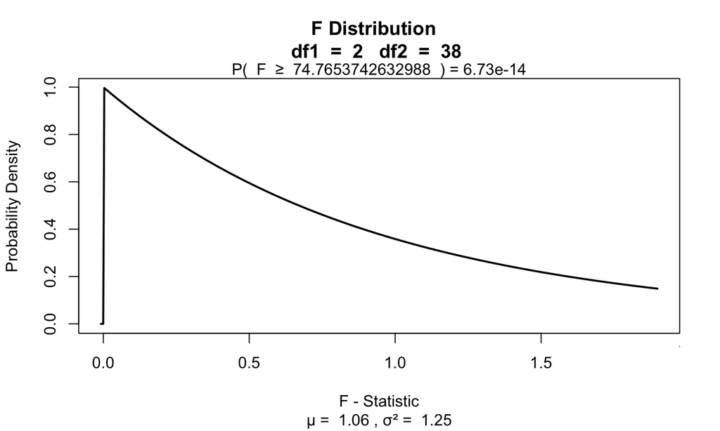

```r
library('visualize')
visualize.f(F, DF_model, DF_error, section="upper")
```

## END

[@shklinkenberg](https://twitter.com/shklinkenberg)